# Ejercicio 3

# Análisis de la serie principal

```r
data <- read.csv2("Ejercicio_031.csv", sep=";")
```

Una vez tenemos los datos los convertimos a xts.

```r
library(forecast)
require(xts)
library(ggplot2)
data1 <- as.xts(ts(data[,2], start = c(1960, 2) , frequency = 12))
```

Convertimos a zoo.

```r
zserie1<-as.zoo(data1)
names(zserie1)="serie"
```

Graficamente.

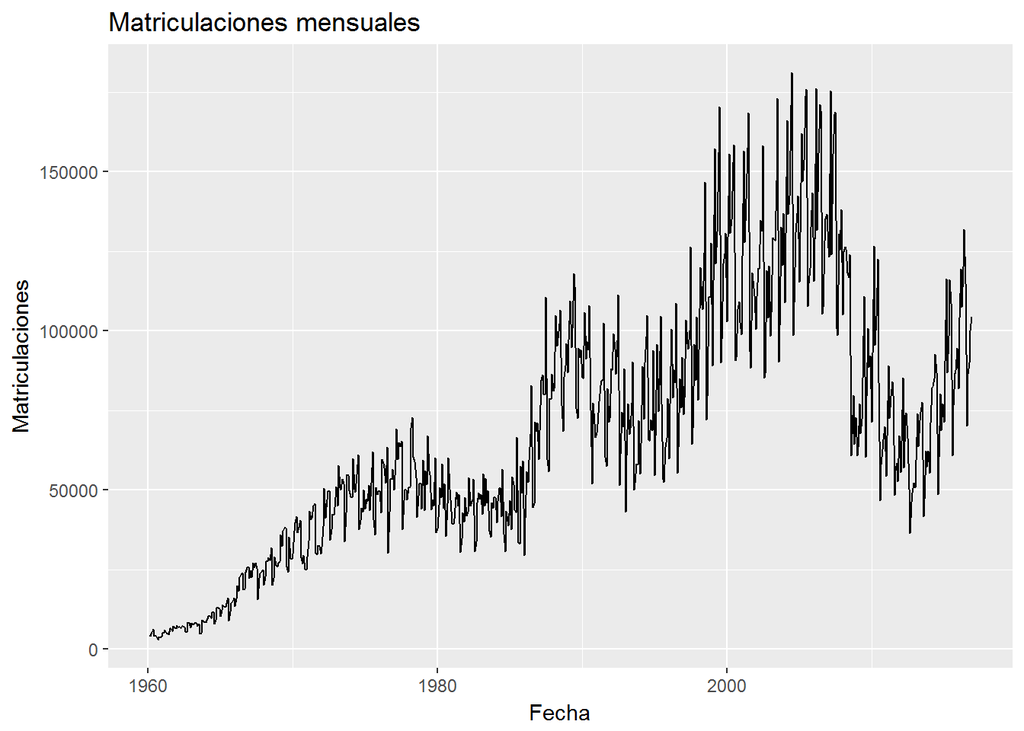

```r
autoplot(zserie1) +
  ggtitle("Matriculaciones mensuales") +
  xlab("Fecha")+ylab("Matriculaciones")
```

Podemos ver que la serie es heteroscedástica, tiene tendencia y parte estacional.

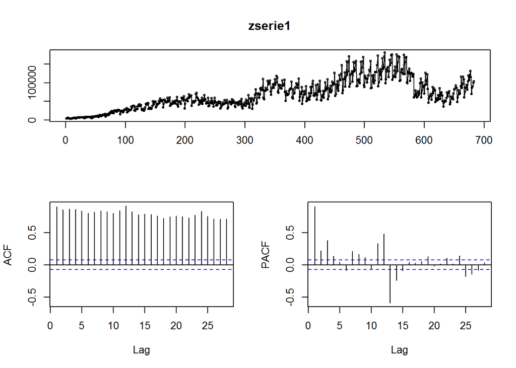

```r
tsdisplay(zserie1)
```

Como vemos por los residuos de la autocrrelación parcial y como decrece la autocorrelación se podría pensar que estamos antes un modelo autorregresivo.

Si añadimos diferencias.

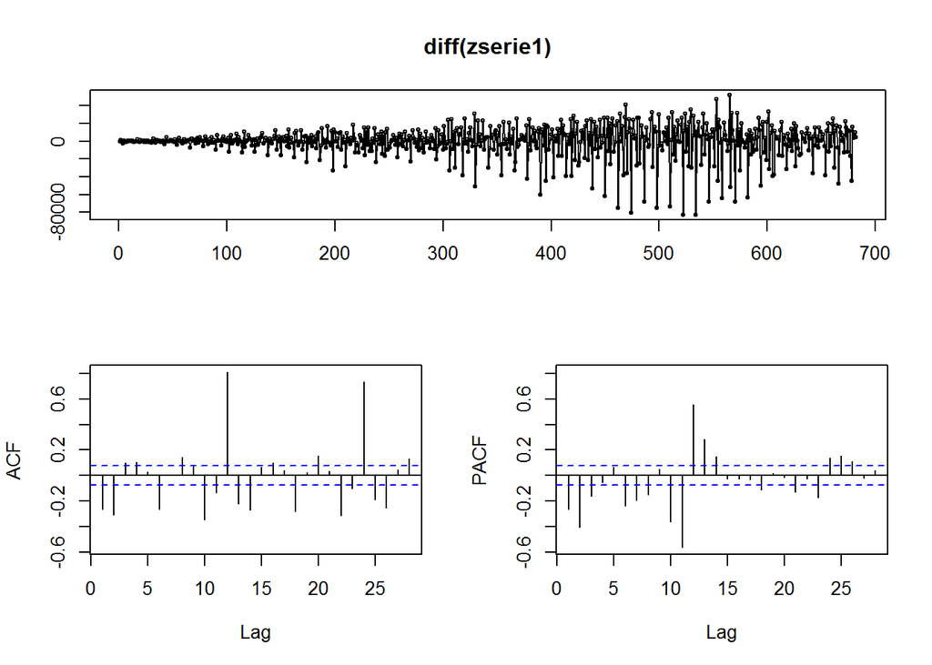

```r
tsdisplay(diff(zserie1))
```

Aquí podemos ver la estacionalidad anual.

Añadimos una diferencia anual para la estacionalidad.

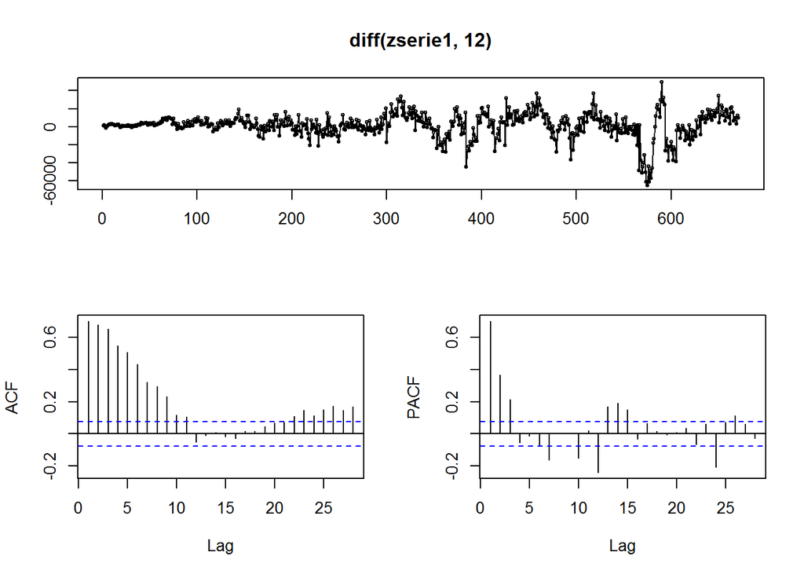

```r
tsdisplay(diff(zserie1, 12))
```

Ahora podemos ver más claramente los residuos que hay que mejorar para convertirlo en ruido blanco (AR de orden 2-3 podría ser).

No voy a trabajar con xts para que no me de problemas a la hora de crear la predicción del Arimax.

```r
data[,1]<- seq(as.Date('1960-02-01'), length.out = nrow(data), by='month')
dataprueba <- data[-c(673:683),]
dataprueba2 <- data[-c(1:673),]
```

dataprueba y dataprueba2 son el train y el test que utilizaré para el modelo.

```r
arima1=Arima(log(dataprueba[,2]),
              lambda = 0,
              order = c(1,1,0),
              seasonal = list(order = c(2,1,0), period= 12))
summary(arima1)
```

```
## Series: log(dataprueba[, 2])
## ARIMA(1,1,0)(2,1,0)[12]
## Box Cox transformation: lambda= 0
##
## Coefficients:
##           ar1     sar1     sar2
##       -0.4154  -0.4834  -0.2768
## s.e.   0.0355   0.0391   0.0396
##
## sigma^2 estimated as 0.0001488:  log likelihood=1968.57
## AIC=-3929.13   AICc=-3929.07   BIC=-3911.17
##
## Training set error measures:
##                         ME      RMSE        MAE         MPE      MAPE
## Training set -0.0006272543 0.1269773 0.09463609 -0.01175584 0.8855813
##                   MASE       ACF1
## Training set 0.5723285 -0.1300888
```

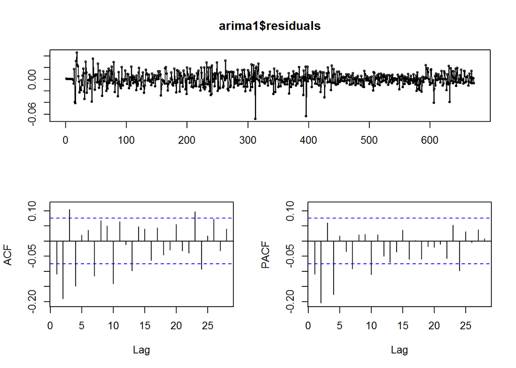

Tras esta primera prueba podemos ver que el modelo necesita una parte de media movil.

```r
arima2=Arima(log(dataprueba[,2]),
              lambda = 0,
              order = c(2,1,2),
              seasonal = list(order = c(2,1,1), period= 12))
summary(arima2)
```

```
## Series: log(dataprueba[, 2])
## ARIMA(2,1,2)(2,1,1)[12]
## Box Cox transformation: lambda= 0
##
## Coefficients:
##           ar1      ar2     ma1      ma2    sar1    sar2     sma1
##       -0.7394  -0.1678  0.2098  -0.2691  0.1838  0.0169  -0.9078
## s.e.   0.1531   0.0936  0.1524   0.1337  0.0470  0.0471   0.0260
##
## sigma^2 estimated as 0.0001183:  log likelihood=2039.8
## AIC=-4063.6   AICc=-4063.37   BIC=-4027.67
##
## Training set error measures:
##                        ME     RMSE        MAE         MPE      MAPE
## Training set -0.005483799 0.112465 0.08259962 -0.05780736 0.7751031
##                   MASE        ACF1
## Training set 0.4995358 -0.01943054
```

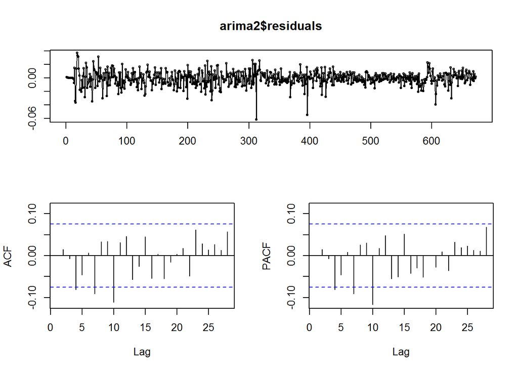

Vamos a comprobar si hay atípicos provocando ruido

```r
library(TSA)
detectAO(arima2)
```

```
## [1] "No AO detected"
```

```r
detectIO(arima2)
```

```
##               [,1]       [,2]       [,3]
## ind     312.000000 396.000000 606.000000
## lambda1  -6.380138  -5.648252  -4.060249
```

Como vemos hay varios atípicos relevantes, voy a deshacer los atípicos introduciendolos como regresores externeos.

```r
arima3=Arima(log(dataprueba[,2]),
              lambda = 0,
              order = c(2,1,2),
              seasonal = list(order = c(2,1,1), period= 12),
              xreg = data.frame(
                outlier1 = 1*(dataprueba$X19601==dataprueba$X19601[312]),
                outlier2 = 1*(dataprueba$X19601==dataprueba$X19601[396]),
                outlier3 = 1*(dataprueba$X19601==dataprueba$X19601[606])
              ))
summary(arima3)
```

```
## Series: log(dataprueba[, 2])
## ARIMA(2,1,2)(2,1,1)[12]
## Box Cox transformation: lambda= 0
##
## Coefficients:
##           ar1     ar2     ma1      ma2    sar1    sar2     sma1  outlier1
##       -0.7015  -0.197  0.2042  -0.2099  0.2160  0.0049  -0.9053   -0.0472
## s.e.   0.1327   0.104  0.1334   0.1262  0.0477  0.0481   0.0269    0.0085
##       outlier2  outlier3
##        -0.0373   -0.0152
## s.e.    0.0085    0.0085
##
## sigma^2 estimated as 0.0001103:  log likelihood=2064.72
## AIC=-4107.45   AICc=-4107.04   BIC=-4058.05
##
## Training set error measures:
##                        ME      RMSE        MAE         MPE      MAPE
## Training set -0.004944868 0.1080866 0.08197223 -0.05243327 0.7685607
##                   MASE        ACF1
## Training set 0.4957416 -0.01981887
```

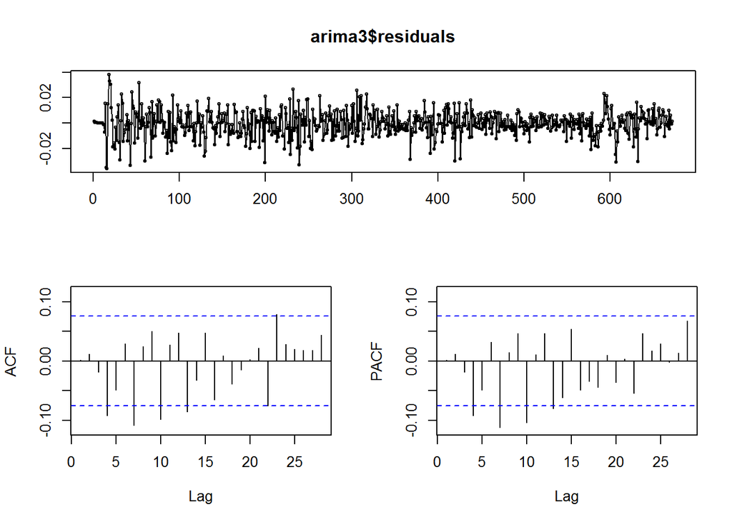

```r
tsdisplay(arima3$residuals)
```

```r
detectAO(arima3)
```

```
## [1] "No AO detected"
```

```r
detectIO(arima3)
```

```
##              [,1]
## ind     18.000000
## lambda1  3.964475
```

Aparecen nuevo outliers y residuos siguen sin ser ruido blanco.

```r
Box.test(arima3$residuals,lag=4, fitdf=3, type="Lj")
```

```
##
##  Box-Ljung test
##
## data:  arima3$residuals
## X-squared = 6.0796, df = 1, p-value = 0.01368
```

```r
Box.test(arima3$residuals,lag=8, fitdf=3, type="Lj")
```

```
##
##  Box-Ljung test
##
## data:  arima3$residuals
## X-squared = 16.74, df = 5, p-value = 0.005019
```

```r
Box.test(arima3$residuals,lag=12, fitdf=3, type="Lj")
```

```
##
##  Box-Ljung test
##
## data:  arima3$residuals
## X-squared = 27.135, df = 9, p-value = 0.001329
```

Vamos a ver como predice el modelo, ya que, los residuos, aun sin estar dentro de los limites, tienen valores muy bajos.

```r
farima3 <- forecast(arima3, xreg=data.frame(
                 outlier1 = 1*(dataprueba$X19601==dataprueba$X19601[312]),
                 outlier2 = 1*(dataprueba$X19601==dataprueba$X19601[369]),
                 outlier3 = 1*(dataprueba$X19601==dataprueba$X19601[606])))
farima3 <- as.data.frame(farima3)
farima3 <- farima3[c(1:10),]
farima3$Mes <- dataprueba2[,1]
matrix(c(farima3[,1],log(dataprueba2[,2])),ncol=2)
```

```
##           [,1]     [,2]
##  [1,] 11.49797 11.68941
##  [2,] 11.72175 11.58473
##  [3,] 11.52496 11.69575
##  [4,] 11.62062 11.78873
##  [5,] 11.73092 11.65149
##  [6,] 11.72610 11.15604
##  [7,] 11.15292 11.36765
##  [8,] 11.27330 11.40802
##  [9,] 11.46340 11.51278
## [10,] 11.43092 11.55617
```

Como vemos el test de predicción sigue, más o menos, los valores reales de cerca

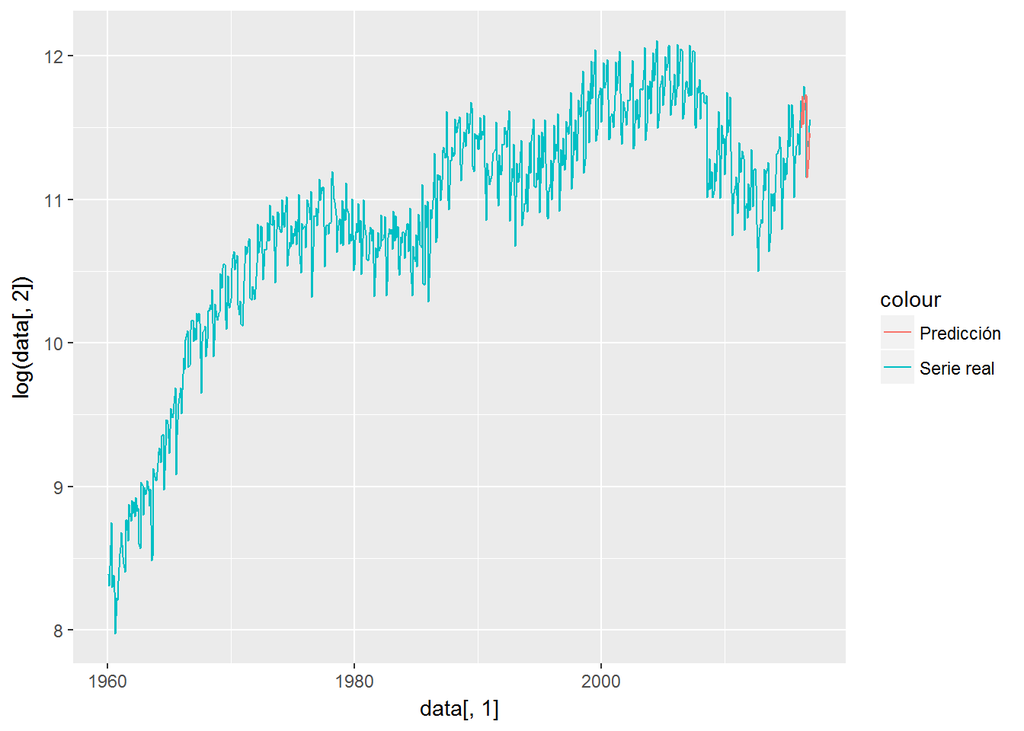

```r
ggplot()+
  geom_line(aes(data[,1], log(data[,2]), colour ="Serie real"), data)+
  geom_line(aes(x=farima3[,6], y=farima3[,1], colour = "Predicción"), farima3)
```

Graficamente parece bastante ajustado, el probelma es que al haber tantas observaciones no se puede ver bien la diferencia.

# Función de transferencias y efecto del crédito

Vamos a crear un Arimax para introducir la función de transferencia para el crédito a las familias.

```r
data2 <- data[c(516:683),]
data2[,3] <- as.numeric(data2[,3])
```

Ahora tenemos las muestra con el crédito para poder crear la función de transferencias.

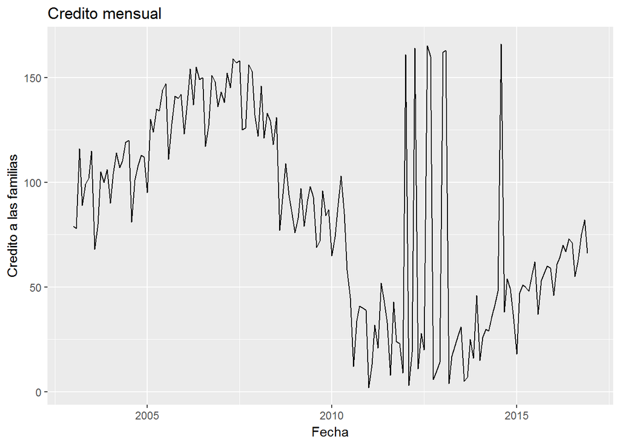

```r
ggplot(data2, mapping = aes(x = data2[,1], y = data2[,3])) +
  geom_line()+
  ggtitle("Credito mensual") +
  xlab("Fecha")+ylab("Credito a las familias")
```

Ahora conocemos como se mueve el crédito, no parece tener tendencia, pero si que es heteroscedástico y tiene estacionalidad.

```r
mat.l <- log(data2[,2])
cred.l <- log(data2[,3])
```

Veamos la estacionalidad.

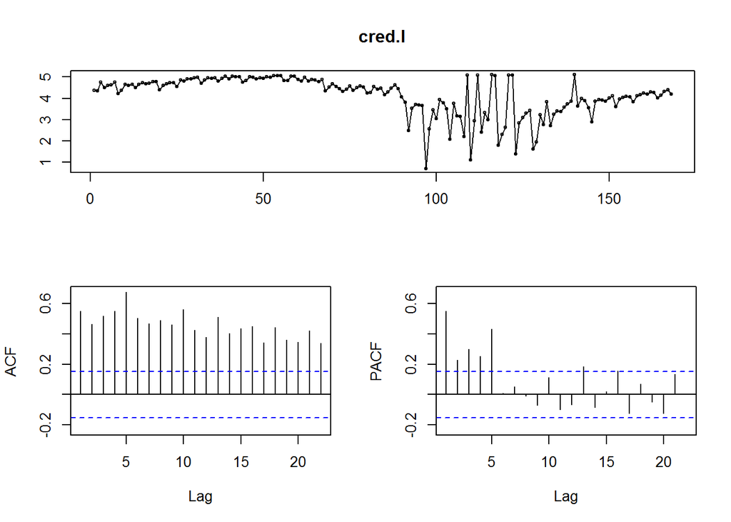

```r
tsdisplay(cred.l)
```

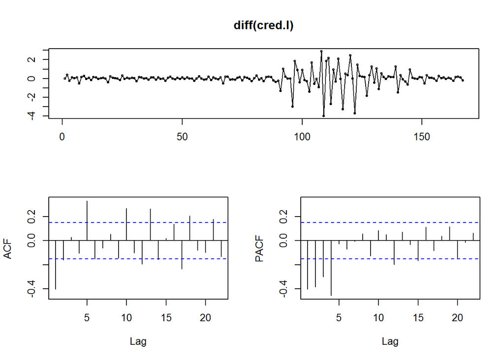

```r
tsdisplay(diff(cred.l))
```

Parece que la estacionalidad podría ser trimestral.

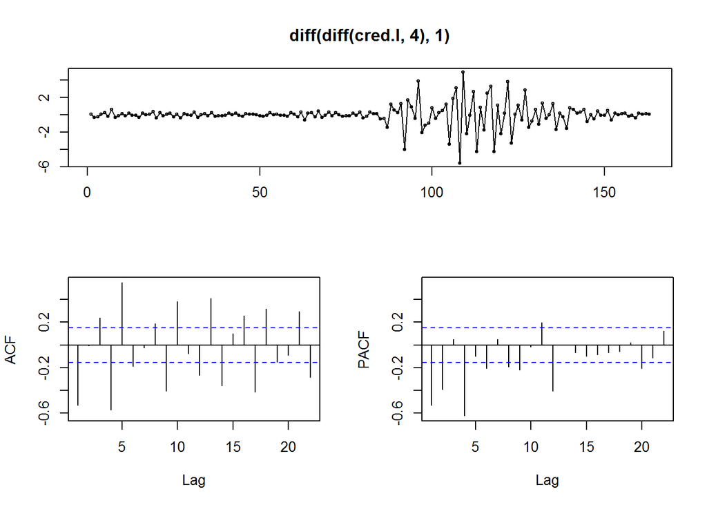

```r
tsdisplay(diff(diff(cred.l, 4),1))
```

Parece que añadir la diferencia trimestral no ayuda.

Veamos la regresión dinámica.

```r
library(Hmisc)
library(dynlm)
library(pander)

mod0=dynlm(mat.l ~ L(cred.l, 1) + L(cred.l, 4) + L(cred.l, 12))
pander(mod0)
```

Fitting linear model: mat.l ~ L(cred.l, 1) + L(cred.l, 4) + L(cred.l, 12)

[output not shown]

Como vemos solo la diferencia se acepta en la regresión dinámica.

```r
arimax1 <- arimax(mat.l,
              order = c(2,1,2),
              include.mean = TRUE,
              seasonal = list(order = c(2,1,1), period= 12),
              xtransf = cred.l,
              transfer = list(c(1,3)),
              method = "ML"
              )
summary(arimax1)
```

```
##
## Call:
## arimax(x = mat.l, order = c(2, 1, 2), seasonal = list(order = c(2, 1, 1), period = 12),
##     include.mean = TRUE, method = "ML", xtransf = cred.l, transfer = list(c(1,
##         3)))
##
## Coefficients:
##           ar1      ar2     ma1     ma2     sar1     sar2     sma1   T1-AR1
##       -1.1264  -0.9542  0.9553  0.8647  -0.0616  -0.0626  -0.7572  -0.4043
## s.e.   0.0330   0.0307  0.0650  0.0670   0.1317   0.1095   0.1208   0.2292
##       T1-MA0   T1-MA1   T1-MA2   T1-MA3
##       0.0080  -0.0193  -0.0084  -0.0182
## s.e.  0.0098   0.0132   0.0121   0.0105
##
## sigma^2 estimated as 0.008031:  log likelihood = 143.5,  aic = -263
##
## Training set error measures:
##                       ME       RMSE        MAE        MPE      MAPE
## Training set 0.001254159 0.08607615 0.06349006 0.01097361 0.5575589
##                   MASE       ACF1
## Training set 0.3634036 -0.1769135
```

Podemos ver como los coeficientes autorregresivos de la parte estacional ya no son muy altos, esto se debe a la reducción de la muestra temporal. Por otro lado la media movil de la función de trans ferencia también tiene valores muy bajos.

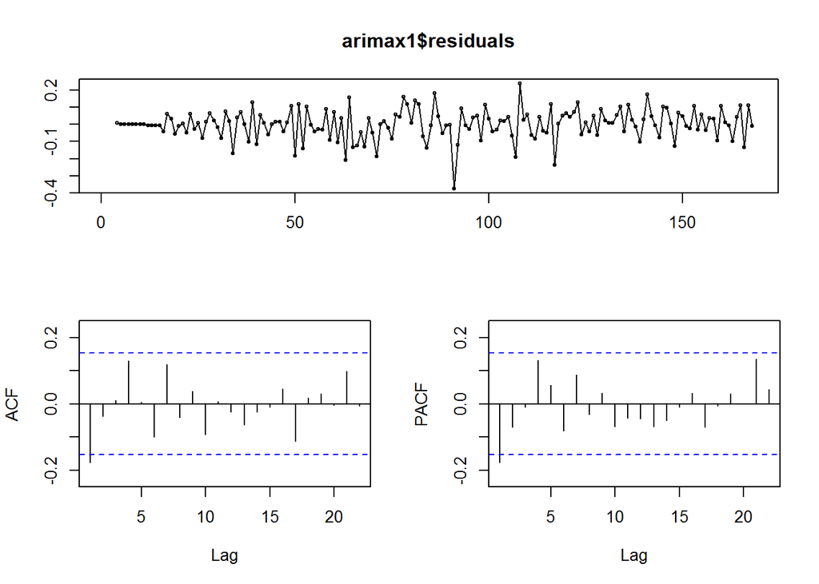

```r
tsdisplay(arimax1$residuals)
```

Como vemos los residuos parecen ruido blanco.

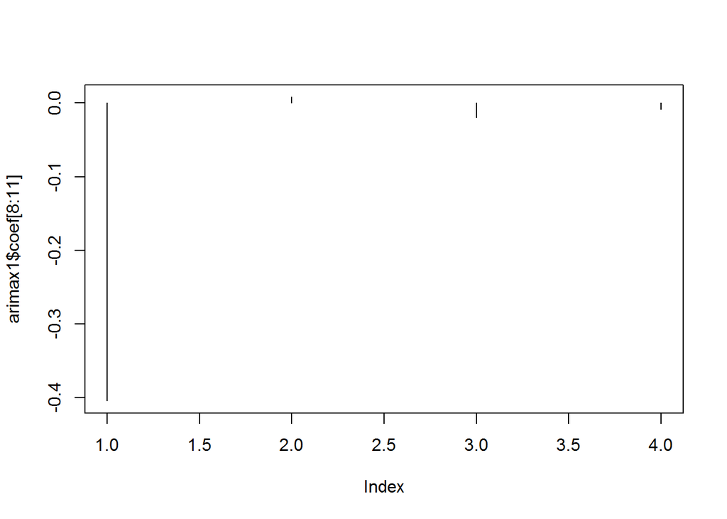

```r
plot(arimax1$coef[8:11],type="h")
```

Como vemos por el valor de los coeficientes en la gráfica solo el primer coeficiente de la función de transferencia (AR1) es dignificativo.

Vamos a quitar la parte autoregresiva estacional de paso y añadimos un AR más, que los coeficientes son muy altos y los residuos muestran que sobre sale un valor.

```r
arimax2 <- arimax(mat.l,
              order = c(3,1,2),
              include.mean = TRUE,
              seasonal = list(order = c(1,1,1), period= 12),
              xtransf = cred.l,
              transfer = list(c(1,0)),
              method = "ML"
              )
summary(arimax2)
```

```
##
## Call:
## arimax(x = mat.l, order = c(3, 1, 2), seasonal = list(order = c(1, 1, 1), period = 12),
##     include.mean = TRUE, method = "ML", xtransf = cred.l, transfer = list(c(1,
##         0)))
##
## Coefficients:
##           ar1     ar2     ar3      ma1      ma2    sar1     sma1   T1-AR1
##       -0.3800  0.1145  0.3213  -0.0729  -0.1998  0.0187  -0.8364  -0.5845
## s.e.   0.4709  0.5191  0.2239   0.4856   0.3594  0.1071   0.0970   0.1937
##       T1-MA0
##       0.0197
## s.e.  0.0080
##
## sigma^2 estimated as 0.008459:  log likelihood = 142.68,  aic = -267.37
##
## Training set error measures:
##                        ME       RMSE        MAE         MPE      MAPE
## Training set -0.001225307 0.08840259 0.06545548 -0.01106222 0.5761577
##                   MASE        ACF1
## Training set 0.3746532 0.001028873
```

```r
detectAO(arimax2)
```

```
##              [,1]
## ind     91.000000
## lambda2 -3.672316
```

```r
detectIO(arimax2)
```

```
##              [,1]
## ind     91.000000
## lambda1 -4.772671
```

Voy a eliminar el IO.

```r
arimax3 <- arimax(mat.l,
              order = c(3,1,2),
              include.mean = TRUE,
              seasonal = list(order = c(1,1,1), period= 12),
              xtransf = cred.l,
              transfer = list(c(1,0)),
              method = "ML",
              io = c(91)
              )
summary(arimax3)
```

```
##
## Call:
## arimax(x = mat.l, order = c(3, 1, 2), seasonal = list(order = c(1, 1, 1), period = 12),
##     include.mean = TRUE, method = "ML", io = c(91), xtransf = cred.l, transfer = list(c(1,
##         0)))
##
## Coefficients:
##           ar1     ar2     ar3      ma1      ma2    sar1     sma1    IO-91
##       -0.2488  0.2954  0.3641  -0.1932  -0.3241  0.0774  -0.8394  -0.4114
## s.e.   0.2945  0.2946  0.1290   0.3081   0.2615  0.0964   0.0724   0.0897
##        T1-AR1  T1-MA0
##       -0.5961  0.0181
## s.e.   0.1738  0.0072
##
## sigma^2 estimated as 0.007497:  log likelihood = 152.59,  aic = -285.18
##
## Training set error measures:
##                       ME       RMSE       MAE         MPE      MAPE
## Training set 0.001011424 0.08323001 0.0631917 0.008640046 0.5562894
##                   MASE        ACF1
## Training set 0.3616958 -0.07084744
```

Este ARIMAX tiene el error más reducido de los 3 y menor AIC.

Evidentemente, el crédito influye, ya que el coeficiente T1-AR1 afecta a la serie.

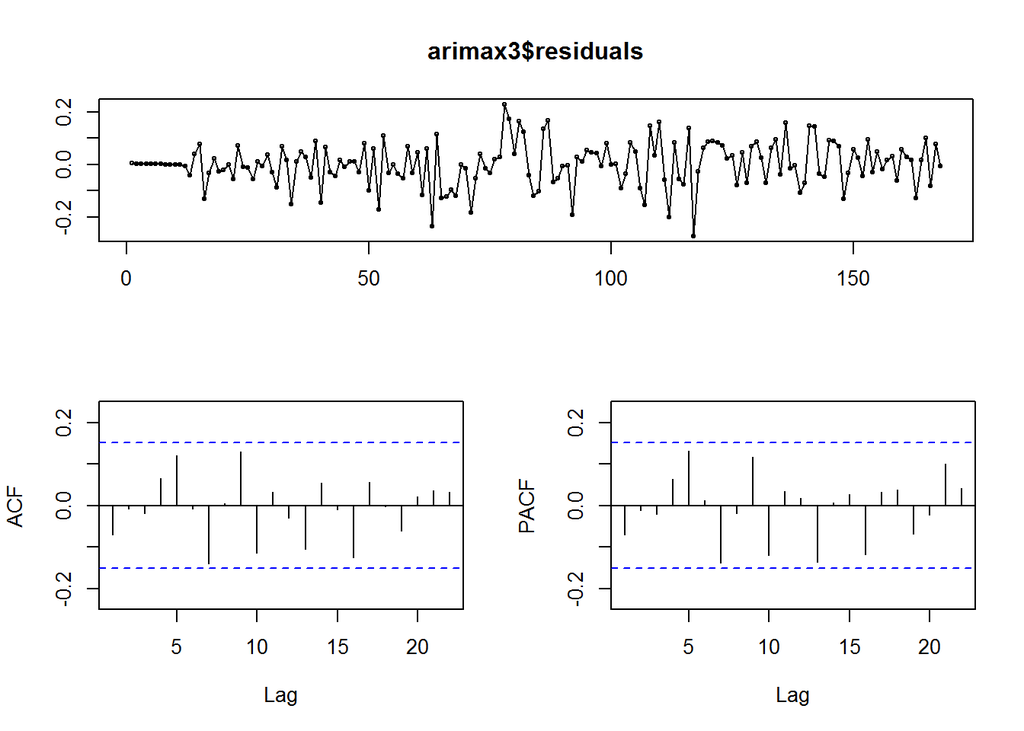

```r
tsdisplay(arimax3$residuals)
```

# Predicción

```r
arima4=Arima(log(data[,2]),
              lambda = 0,
              order = c(2,1,2),
              seasonal = list(order = c(2,1,1), period= 12),
              xreg = data.frame(
                outlier1 = 1*(data$X19601==data$X19601[312]),
                outlier2 = 1*(data$X19601==data$X19601[396]),
                outlier3 = 1*(data$X19601==data$X19601[606])
              ))
summary(arima4)
```

```
## Series: log(data[, 2])
## ARIMA(2,1,2)(2,1,1)[12]
## Box Cox transformation: lambda= 0
##
## Coefficients:
##           ar1      ar2     ma1      ma2    sar1    sar2     sma1  outlier1
##       -0.7092  -0.1978  0.2090  -0.2145  0.2166  0.0080  -0.9046   -0.0473
## s.e.   0.1312   0.1023  0.1319   0.1254  0.0476  0.0476   0.0271    0.0084
##       outlier2  outlier3
##        -0.0372   -0.0148
## s.e.    0.0085    0.0084
##
## sigma^2 estimated as 0.0001091:  log likelihood=2102.97
## AIC=-4183.95   AICc=-4183.54   BIC=-4134.37
##
## Training set error measures:
##                        ME      RMSE        MAE         MPE      MAPE
## Training set -0.004740733 0.1075877 0.08162401 -0.05046028 0.7646389
##                   MASE        ACF1
## Training set 0.4940692 -0.02001415
```

```r
farima4 <- forecast(arima4, h = 20, xreg=data.frame(
                 outlier1 = 1*(data$X19601==data$X19601[312]),
                 outlier2 = 1*(data$X19601==data$X19601[369]),
                 outlier3 = 1*(data$X19601==data$X19601[606])))
farima4 <- as.data.frame(farima4)
vector<-seq(as.POSIXct("2017-01-01"), as.POSIXct("2018-12-1"), "months")
farima4 <- farima4[c(1:24),]
farima4$Mes <- as.Date(vector)
dates <- matrix(nrow=24, ncol=3)
dates <- as.data.frame(dates)
colnames(data) <- c("1","2","3")
colnames(dates) <- c("1", "2", "3")
datae <- rbind(data, dates)
datae[,1]<- seq(as.Date('1960-02-01'), length.out = nrow(datae), by='month')
```

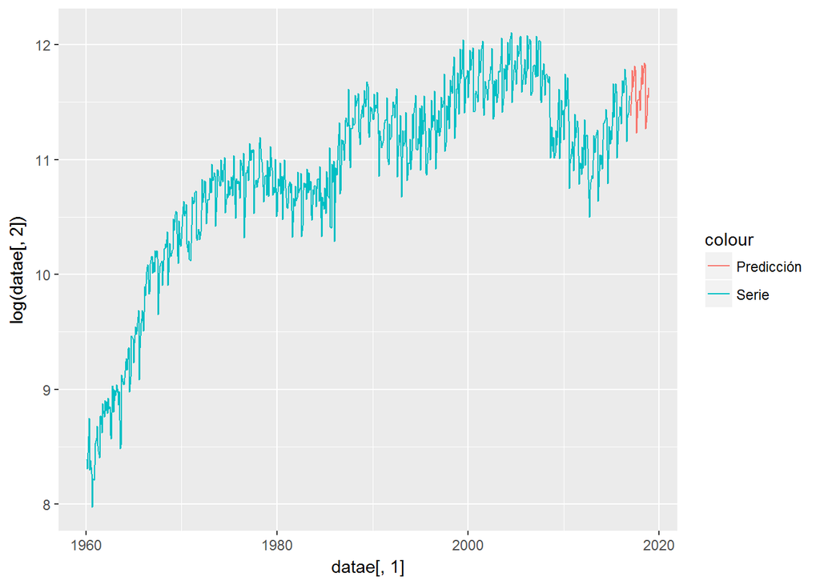

```r
ggplot()+
  geom_line(aes(datae[,1], log(datae[,2]), colour ="Serie"), datae)+
  geom_line(aes(x=farima4[,6], y=farima4[,1], colour = "Predicción"), farima4)
```

Como vemos la predicción sin crédito parece bastante buena.

Con el ARIMAX también podriamos hacer una predicción, pero como no consigo saber como predecir con el pueo crear un arima con regresor externo, que no será igual de bueno, pero servirá.

```r
arimareg = Arima(log(data2[,2]),
              lambda = 0,
              order = c(3,1,2),
              seasonal = list(order = c(1,1,1), period= 12),
              xreg = data.frame(
                credito = log(data2[,3])
              ))
summary(arimareg)
```

```
## Series: log(data2[, 2])
## ARIMA(3,1,2)(1,1,1)[12]
## Box Cox transformation: lambda= 0
##
## Coefficients:
##           ar1     ar2     ar3     ma1      ma2    sar1     sma1  credito
##       -0.4633  0.1318  0.3369  0.0215  -0.2726  0.0320  -0.8501   0.0016
## s.e.   0.4497  0.5280  0.2287  0.4620   0.3799  0.1054   0.0984   0.0008
##
## sigma^2 estimated as 7.152e-05:  log likelihood=516.93
## AIC=-1015.85   AICc=-1014.61   BIC=-988.46
##
## Training set error measures:
##                        ME      RMSE        MAE        MPE     MAPE
## Training set -0.001287172 0.0897153 0.06621082 -0.0119862 0.582588
##                   MASE        ACF1
## Training set 0.3789767 -0.01092756
```

Como podemos apreciar por el coeficiente de crédito al meterlo como regresor externo el coeficiente es insignificativo, mientras que en transferencias si que mostraba significatividad.

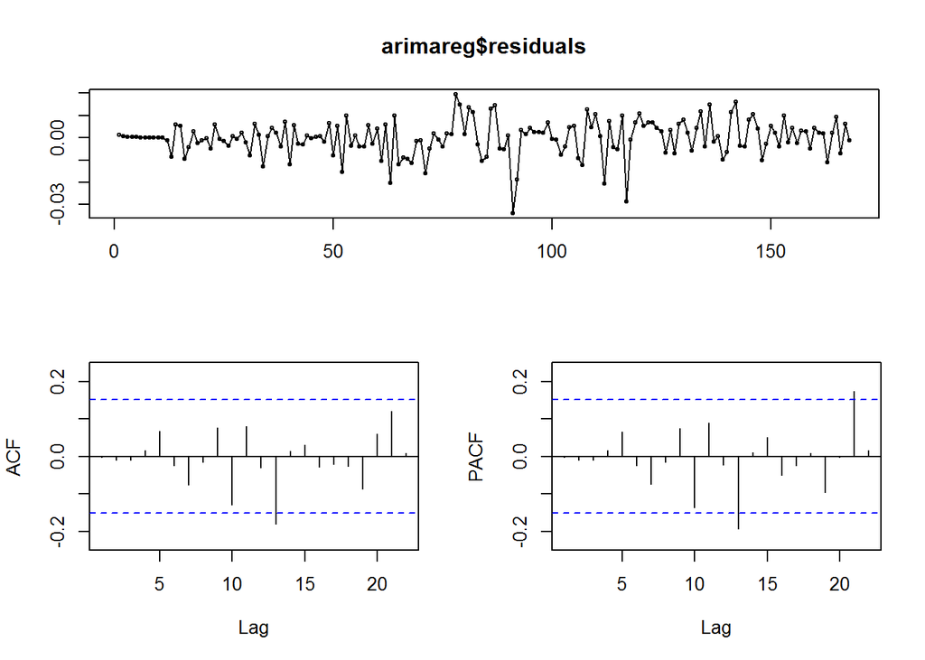

```r
tsdisplay(arimareg$residuals)
```

```r
farimareg <- forecast(arimareg, h = 12, xreg=data.frame(
                 credito = log(data2[,3])))
farimareg <- as.data.frame(farimareg)
vector2<-seq(as.POSIXct("2017-01-01"), as.POSIXct("2017-6-1"), "months")
farimareg <- farimareg[c(1:6),]
farimareg$Mes <- as.Date(vector2)
dates2 <- matrix(nrow=6, ncol=3)
dates2 <- as.data.frame(dates)
colnames(data2) <- c("1","2","3")
colnames(dates2) <- c("1", "2", "3")
datae2 <- rbind(data2, dates2)
datae2[,1]<- seq(as.Date('2003-01-01'), length.out = nrow(datae2), by='month')
```

El plot con regresivo sería:

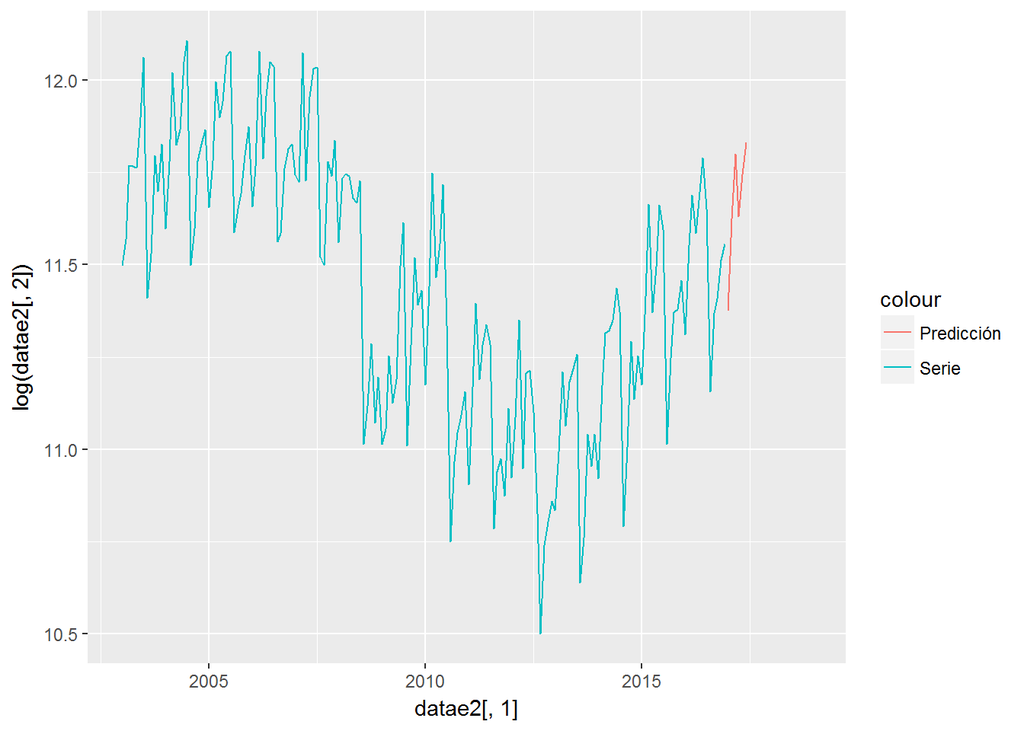

```r
ggplot()+
  geom_line(aes(datae2[,1], log(datae2[,2]), colour ="Serie"), datae2)+
  geom_line(aes(x=farimareg[,6], y=farimareg[,1], colour = "Predicción"), farimareg)
```

Este último modelo ARIMA no recoge muy bien el final de la serie, pero parece que se corrige poco a poco.

Como conclusión podemos decir que si que hemos podido predecir la venta de matriculas para los próximos 2 años, que aparentemente serán al alza. Y que la concesión de créditos si que afecta, como pudimos ver en transferencias, pero en regresivo el coeficiente es muy bajo.